# Diffusion processes on complex networks - assignment 1

### Mateusz Dzitkowski 249777

## Exercise 1

We are tasked with implementing three random graph generators, the code is displayed below.

```python
from itertools import combinations
from random import random, choice

from matplotlib import pyplot as plt
from networkx import Graph
import networkx as nx
from nptyping import NDArray
import numpy as np
import scipy as sp
from pandas import read_csv
```

```python
def erdos_renyi(number_of_nodes: int, edge_probability: float) -> Graph:
    assert 0 <= edge_probability <= 1
    assert number_of_nodes > 0

    g = Graph()
    g.add_nodes_from(range(number_of_nodes))

    for _from, _to in combinations(range(number_of_nodes), 2):
        if random() < edge_probability:
            g.add_edge(_from, _to)

    return g
```

```python
def watts_strogatz(number_of_nodes: int, initial_neighbours: int, rewire_probability: float) -> Graph:
    assert 0 <= rewire_probability <= 1
    assert 0 < initial_neighbours <= number_of_nodes

    g = Graph()
    nodes = list(range(number_of_nodes))

    # initial edges
    for j in range(1, initial_neighbours // 2 + 1):
        targets = nodes[j:] + nodes[0:j]
        g.add_edges_from(zip(nodes, targets))

    # rewired edges
    for j in range(1, initial_neighbours // 2 + 1):
        targets = nodes[j:] + nodes[0:j]
        for u, v in zip(nodes, targets):
            if random() > rewire_probability:
                continue

            w = choice(nodes)
            while w == u or g.has_edge(u, w):
                w = choice(nodes)
                if g.degree(u) >= number_of_nodes - 1:
                    break
            else:
                g.remove_edge(u, v)
                g.add_edge(u, w)
    return g
```

```python
def _random_subset(seq: list, m: int):
    targets = set()
    while len(targets) < m:
        targets.add(choice(seq))
    return targets

def barabasi_albert(number_of_nodes: int, edges_attached: int) -> Graph:
    g = nx.star_graph(edges_attached)
    assert 1 <= edges_attached < number_of_nodes
    assert edges_attached <= len(g) <= number_of_nodes

    nodes_weighted = [node for node, degree in g.degree() for _ in range(degree)]

    source = len(g)
    while source < number_of_nodes:
        targets = _random_subset(nodes_weighted, edges_attached)
        g.add_edges_from(zip([source] * edges_attached, targets))
        nodes_weighted.extend(list(targets) + [source] * edges_attached)
        source += 1

    return g
```

```python
def degrees(g: Graph) -> NDArray:
    return np.array([item[1] for item in g.degree()])

def plot_log_log_degree_frequency(g: Graph):
    unique, counts = np.unique(degrees(g), return_counts=True)
    ax = plt.gca()
    ax.plot(unique, counts / len(unique), "o")
    ax.set_yscale('log')
    ax.set_xscale('log')
    plt.xlabel("k")
    plt.ylabel("p_k")
```

### Erdos-Renyi

Let's investigate the first, Erdos-Renyi, graph. We will generate a graph for various amount of parameters, compute some statistics, and fit a model distribution to the degree data.

```python
N = 2000
p = np.arange(0.05, 1, step=0.05)
graphs = [erdos_renyi(N, _p) for _p in p]
```

Below we can see the number of edges, mean and variance of degree distributions, and the frequency plot of the degree distribution of the Erdos-Renyi random graph.

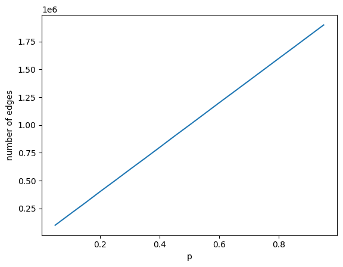

```python
plt.plot(p, [len(g.edges) for g in graphs])
plt.xlabel("p")
plt.ylabel("number of edges")
```

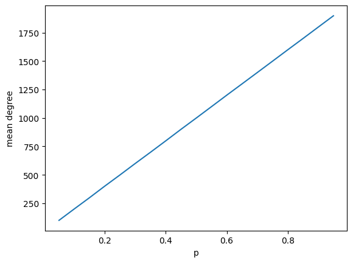

```python
plt.plot(p, [degrees(g).mean() for g in graphs])
plt.xlabel("p")
plt.ylabel("mean degree")
```

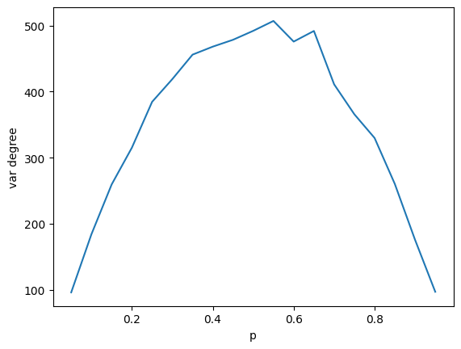

```python
plt.plot(p, [degrees(g).var() for g in graphs])
plt.xlabel("p")
plt.ylabel("var degree")
```

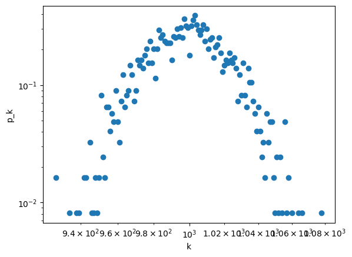

```python
index = 9
plot_log_log_degree_frequency(graphs[index])
```

Now we'll try to fit the model distribution to the data we obtained. In the case of Erdos-Renyi model, it's the binomial distribution.

```python
index = 1
_p = p[index]
sp.stats.fit(
    sp.stats.binom,
    degrees(graphs[index]),
    bounds=[(1900, 2100), (0, 1)],
).params
```

```
FitParams(n=2051.0, p=0.09744369608312829, loc=0.0)
```

As we can see, the fitted values are very close to the values that we used to generate the graph.

### Watts-Strogatz

Now we'll do the same thing for the Watts-Strogatz model, for varying values of $m$ and $p$

```python
N = 2000
m = np.array([2, 4, 10, 20])
p = np.arange(0.05, 1, step=0.05)
graphs = [[watts_strogatz(N, _m, _p) for _p in p] for _m in m]
```

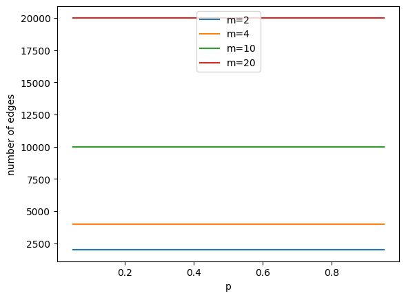

```python
for _m, row in zip(m, graphs):
    plt.plot(p, [len(g.edges) for g in row], label=f"m={_m}")
plt.xlabel("p")
plt.ylabel("number of edges")
plt.legend()
```

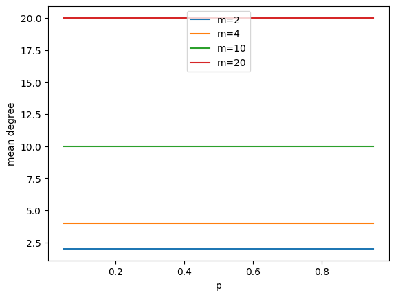

```python
for _m, row in zip(m, graphs):
    plt.plot(p, [degrees(g).mean() for g in row], label=f"m={_m}")
plt.xlabel("p")
plt.ylabel("mean degree")
plt.legend()
```

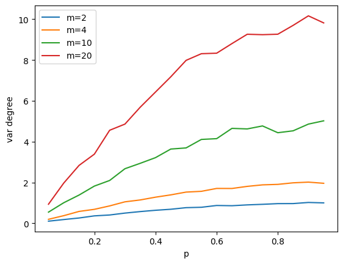

```python
for _m, row in zip(m, graphs):
    plt.plot(p, [degrees(g).var() for g in row], label=f"m={_m}")
plt.xlabel("p")
plt.ylabel("var degree")
plt.legend()
```

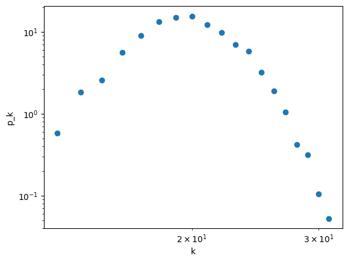

```python
i, j = 3, 10
plot_log_log_degree_frequency(graphs[i][j])
```

Now let's fit a Poisson distribution to the degrees data.

```python
i, j = 3, 4
_m = m[i]
_p = p[j]
sp.stats.fit(
    sp.stats.poisson,
    degrees(graphs[i][j]) - _m,
    bounds=[(0, 100)],
).params
```

```
FitParams(mu=1.426961796372045, loc=0.0)
```

### Barabasi-Albert

Now we'll do yet the same thing, this time for the Barabasi-Albert model, and varying $m$

```python
N = 2000
m = np.arange(1, 30, 1)
graphs = [barabasi_albert(N, _m) for _m in m]
```

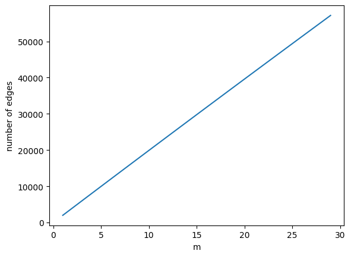

```python
plt.plot(m, [len(g.edges) for g in graphs])
plt.xlabel("m")
plt.ylabel("number of edges")
```

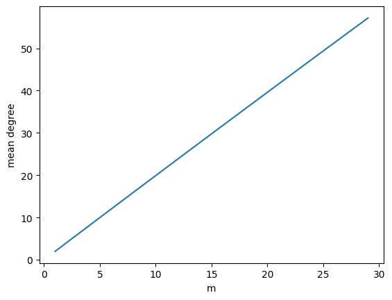

```python
plt.plot(m, [degrees(g).mean() for g in graphs])
plt.xlabel("m")
plt.ylabel("mean degree")
```

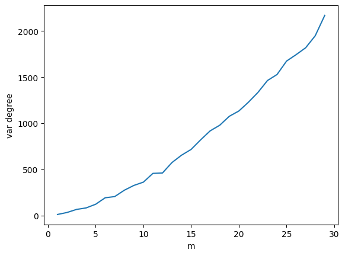

```python
plt.plot(m, [degrees(g).var() for g in graphs])
plt.xlabel("m")
plt.ylabel("var degree")
```

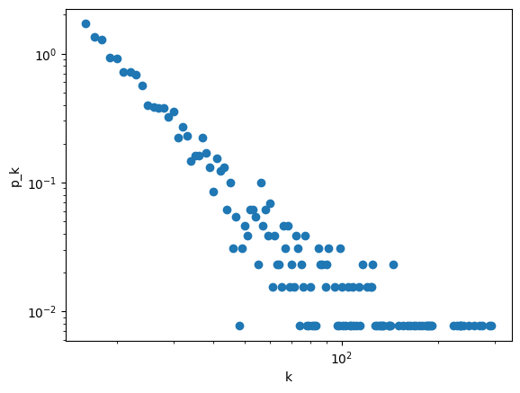

```python
index = 15
plot_log_log_degree_frequency(graphs[index])
```

Now let's fit the power law distribution to the data. We will take the logarithm of $x$s and $y$s, and fit that to a linear function. Thus we will get the parameters back

```python
index = 20
_m = m[index]
g = graphs[index]
x, y = np.unique(degrees(g), return_counts=True)
log_x = np.log(x)
log_y = np.log(y)

def linear_law(x, a, b):
    return a + b * x

popt_log, pcov_log = sp.optimize.curve_fit(linear_law, log_x, log_y)
print(f"a = {popt_log[0]}, b = {popt_log[1]}")
```

```
a = 10.089214707550365, b = -1.9224405795257393
```

## Exercise 2

For this task I've chosen Wikipedia, the Polish language part that is. The Articles are the nodes in the graph, and the links that you can find in an article are the edges. The scraping script, scraper.py, outputs the links into a csv file. Let's load the edges into a networkx graph. The scraping starts ad the article "Adam Małysz".

```python
def from_csv(file_name: str) -> nx.Graph:
    data = read_csv(file_name)
    return nx.from_pandas_edgelist(data, create_using=nx.Graph())
```

```python
g = from_csv("adam_malysz_only_in_20_1000.csv")
```

And check the number of nodes and edges. Keep in mind that I have not scraped the entirety of wikipedia, only a handfull of articles.

```python
print(f"""
Number of nodes = {len(g.nodes)}
Number of edges = {len(g.edges)}
""")
```

```
Number of nodes = 18830
Number of edges = 1039437
```

That's quite big, considering the fact that I spent only about an hour scraping Wikipedia. Now, let's find the celebrities, that is the nodes with the most degree centrality.

```python
for i, (article, degree_centrality) in enumerate(sorted(nx.degree_centrality(g).items(), reverse=True, key=lambda x: x[1])[:10]):
    print(f"{i+1:2d}. {degree_centrality=:.3f} {article}")
```

```
 1. degree_centrality=0.565 Kontrola autorytatywna
 2. degree_centrality=0.456 Encyklopedia internetowa
 3. degree_centrality=0.441 Virtual International Authority File
 4. degree_centrality=0.410 Gemeinsame Normdatei
 5. degree_centrality=0.386 Library of Congress Control Number
 6. degree_centrality=0.356 WorldCat
 7. degree_centrality=0.319 Polska
 8. degree_centrality=0.318 Biblioteka Narodowa Izraela
 9. degree_centrality=0.306 Biblioteka Narodowa Republiki Czeskiej
10. degree_centrality=0.280 Encyklopedia Britannica
```

The most degree centrality will by principle belong to the articles that the most other articles link to, since the articles aren't usually that wordy.

It so happens that the first few articles are very often linked in the foot of other articles, they usually don't have anything in common, just some niche technicality.

Then there's Polska, which actually makes sense, since most of the articles refer to stuff or people from Poland.

Let's check the graph for the friend paradox. We will calculate the number of nodes that have less neighbours than the mean of their neighbours' neighbours.

```python
degree_map = nx.degree(g)
mean_neighbours_degree = np.array([np.array([degree_map[neighbour] for neighbour in nx.neighbors(g, node)]).mean() for node in g.nodes])
d = np.array(degrees(g))
```

```python
print(f"""
Number of nodes that fill the friend paradox criteria = {np.where(d < mean_neighbours_degree, 1, 0).sum()}
Number of nodes that don't = {np.where(d >= mean_neighbours_degree, 1, 0).sum()}
""")
```

```
Number of nodes that fill the friend paradox criteria = 18421
Number of nodes that don't = 409
```

The friend paradox in Wikipedia apparently is very strong.

Now let's see the log-log scatter plot of degree distribution

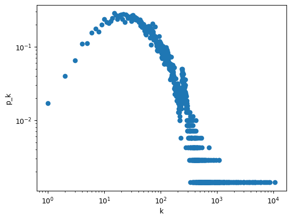

```python
plot_log_log_degree_frequency(g)
```

It does look weird at the start but from some point it starts exhibiting the power law for large $k$. Also there's a hiccup between $10^2$ and $10^3$, not sure what the explanation could be.

The next point deals with a computation-heavy task, so I will truncate the dataset to only include some of the edges.

```python
def from_csv_truncated(file_name: str, num: int) -> nx.Graph:
    data = read_csv(file_name).sample(num)
    return nx.from_pandas_edgelist(data, create_using=nx.Graph())
```

```python
g = from_csv_truncated("adam_malysz_only_in_20_1000.csv", 5_000)
```

Let's see the log-log plot

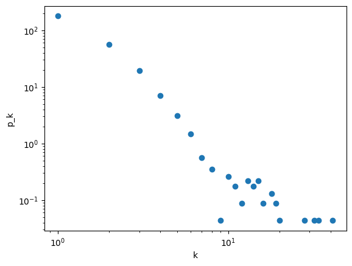

```python
plot_log_log_degree_frequency(g)
```

Again, it seems like it's almost the power law, with less weirdness at small $k$ this time.

Now let's find the communication bottlenecks, that is, the nodes with the largest betweenness centrality.

```python
bc = nx.betweenness_centrality(g)
```

```python
for i, (article, bc) in enumerate(sorted(bc.items(), reverse=True, key=lambda x: x[1])[:10]):
    print(f"{i+1:2d}. {bc=:.3f} {article}")
```

```
 1. bc=0.039 Stany Zjednoczone
 2. bc=0.033 Francja
 3. bc=0.029 Biblioteka Narodowa Republiki Czeskiej
 4. bc=0.027 Vincent Vittoz
 5. bc=0.025 Kontrola autorytatywna
 6. bc=0.023 Martin Švagerko
 7. bc=0.022 Gemeinsame Normdatei
 8. bc=0.021 Rosja
 9. bc=0.021 Encyklopedia internetowa
10. bc=0.021 Wigiliusz (papież)
```

Now let's visualize the whole network. I used https://cosmograph.app/ to visualize my network, because it has a huge amount of nodes and edges. The edges are not shown though because it gets extremely messy. Instead, the nodes that are connected are drawn towards each other, sort of like gravity.

Here's the entire network:

[figure not shown]

```python
from IPython.display import Image
Image(filename="graph_1.jpeg")
```

We can see some clusters forming, and some small communities emerge, usually they correspond to a niche subject.

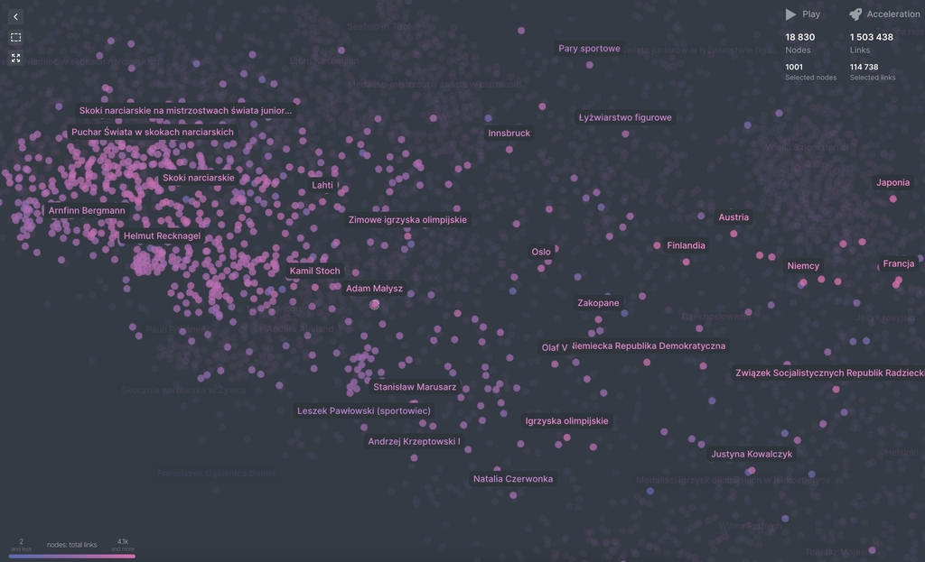

```python
Image(filename="graph_2.jpeg")
```

Above we can see what is the neighbourhood of Adam Małysz, mostly other ski jumpers, some sport-specific stuff, and the countries that frequently hold ski jumping competitions.

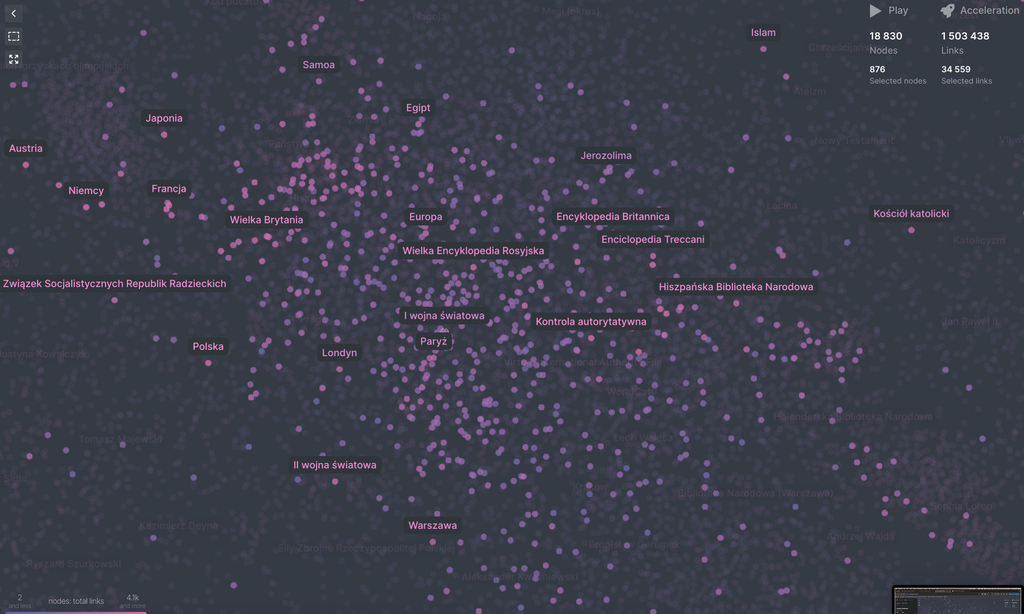

```python
Image(filename="graph_4.jpeg")
```

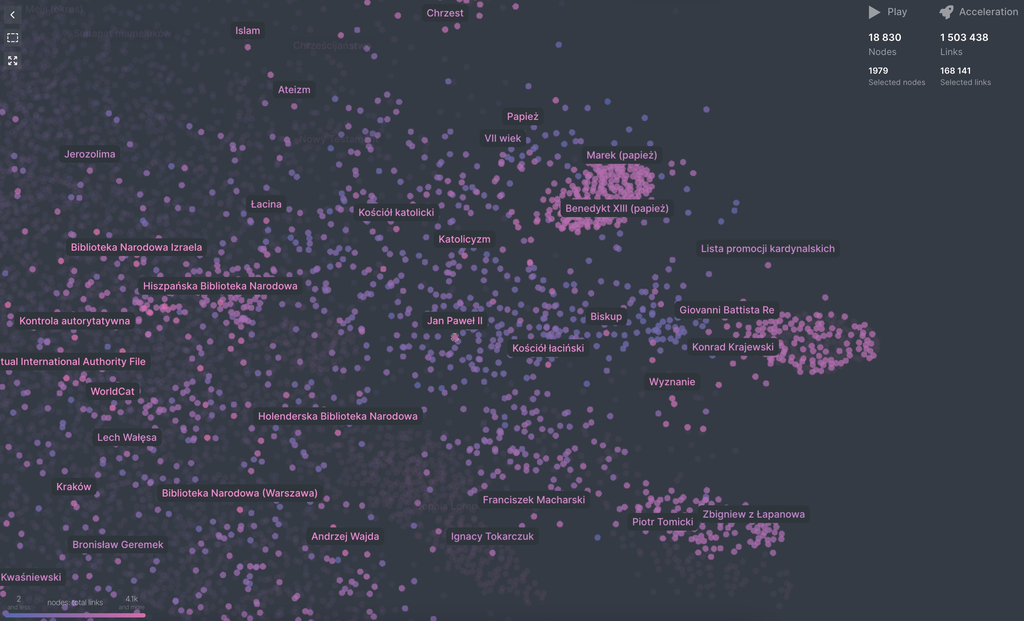

```python
Image(filename="graph_5.jpeg")
```

Here's the John Paul II neighbourhood. As you can imagine, it's mostly religious stuff, other popes, probably some cardinals, also Kraków, where Frańciszkańska street is (I was there last week by the way).

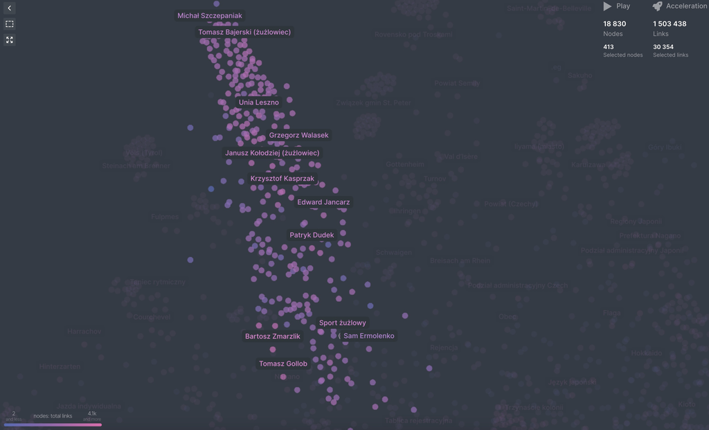

```python
Image(filename="graph_6.jpeg")
```

I also took a glance at one of the small communities, blobs on the edge of the graph. It was Motorcycle Speedway sport, and the nodes in this neighbourhood are almost exclusively known Polish representatives.